# Cbind Result

#### Supplemental Figure 4

**Supplemental Figure 4 Gut microbial alterations throughout the Entire Study**. A, unconstrained PCoA of gut microbiota genes. Principal coordinate analysis of microbiota genes throughout the trial (N = 47). Shadow encompass the range of changes in the microbiota of each individual as measured across three gut microbiome samples, indicating that the overall microbiome signature of subjects changes unique throughout the study (ANOVA p < 10e-20 on each PCoA). B-D, Beta-diversity, Shannon a-diversity, Gene Richness are no significant difference. two-tailed Paired Wilcoxon rank-sum test was used, ns: no significance. E-F, Stacked column bar graphs depict the Relative abundance of the top 20 gut genera and species before and after Dietary Intervention.

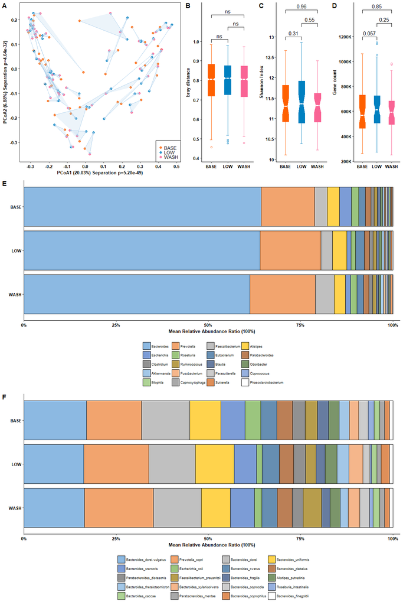

#### Supplemental Figure 5

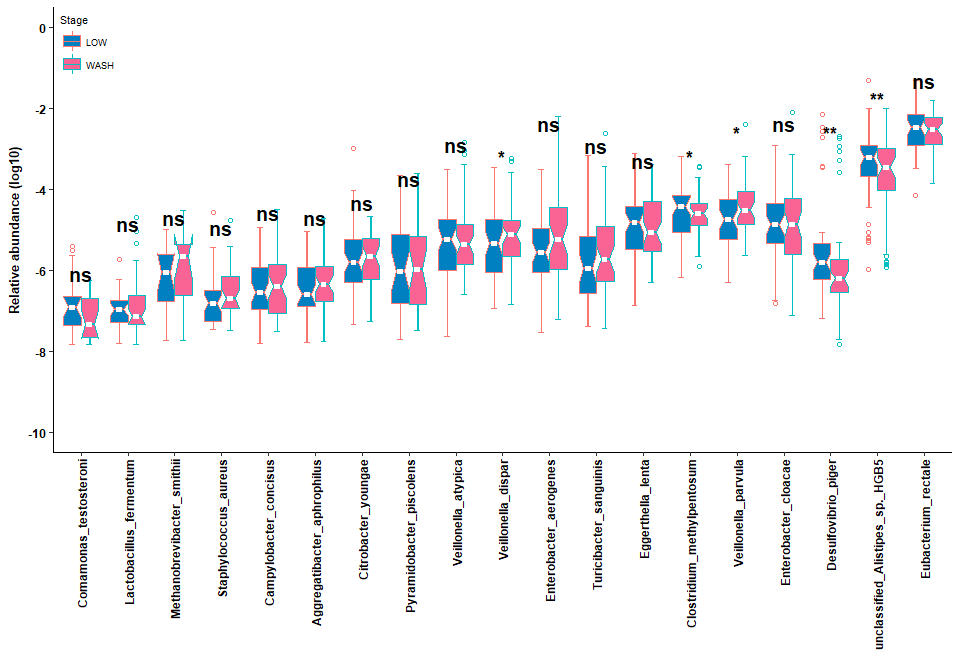